# Coursera Project Week 2

Jeonseo David Lee

2023-07-03

# Loading and preprocessing the data

Show any code that is needed to

**1. Load the data**

```r
data = read.csv("activity.csv")
View(data)
```

**2. Process/transform the data (if necessary) into a format suitable for your analysis**

Needs to convert str format of date column into date format.

```r
str(data)
```

```
## 'data.frame':    17568 obs. of  3 variables:
##  $ steps   : int  NA NA NA NA NA NA NA NA NA NA ...
##  $ date    : chr  "2012-10-01" "2012-10-01" "2012-10-01" "2012-10-01" ...
##  $ interval: int  0 5 10 15 20 25 30 35 40 45 ...
```

```r
data$date <-as.Date(data$date)
str(data)
```

```
## 'data.frame':    17568 obs. of  3 variables:
##  $ steps   : int  NA NA NA NA NA NA NA NA NA NA ...
##  $ date    : Date, format: "2012-10-01" "2012-10-01" ...
##  $ interval: int  0 5 10 15 20 25 30 35 40 45 ...
```

```r
head(data,3)
```

```
##   steps       date interval
## 1    NA 2012-10-01        0
## 2    NA 2012-10-01        5
## 3    NA 2012-10-01       10
```

## What is mean total number of steps taken per day?

For this part of the assignment, you can ignore the missing values in the dataset.

**1. Calculate the total number of steps taken per day**

```r
library(dplyr)
total_steps = data %>%
     group_by(date) %>%
     summarise(total_steps = sum(steps))
```

**2. If you do not understand the difference between a histogram and a barplot, research the difference between them. Make a histogram of the total number of steps taken each day**

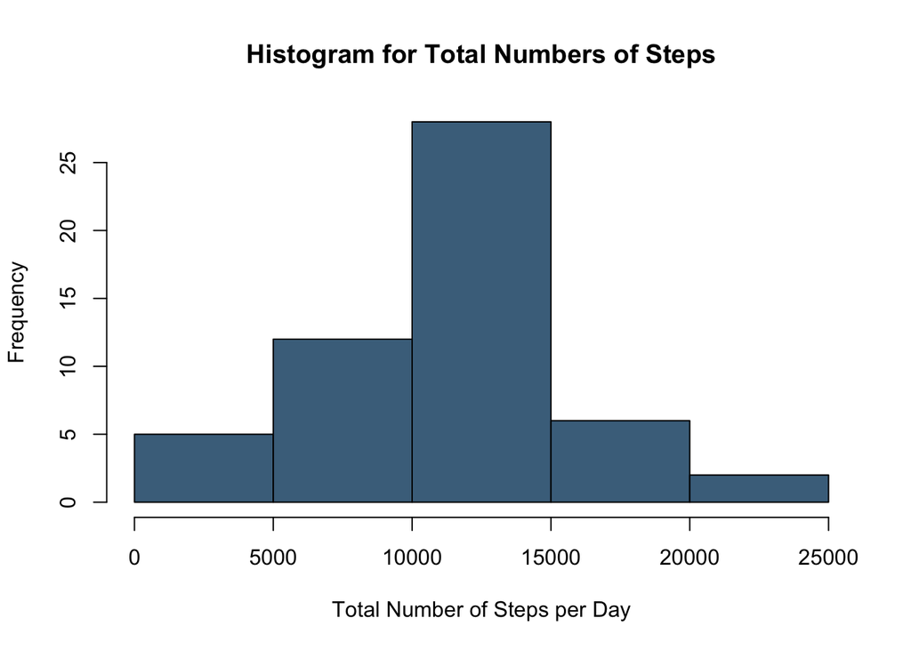

```r
hist(total_steps$total_steps, xlab="Total Number of Steps per Day", main="Histogram for Total Numbers of Steps", col="skyblue4")
```

**3. Calculate and report the mean and median of the total number of steps taken per day**

```r
# Mean Steps
mean_steps = data %>%
     group_by(date) %>%
     summarise(mean_steps = mean(steps))

mean_steps
```

```
## # A tibble: 61 × 2
##    date       mean_steps
##    <date>          <dbl>
##  1 2012-10-01     NA
##  2 2012-10-02      0.438
##  3 2012-10-03     39.4
##  4 2012-10-04     42.1
##  5 2012-10-05     46.2
##  6 2012-10-06     53.5
##  7 2012-10-07     38.2
##  8 2012-10-08     NA
##  9 2012-10-09     44.5
## 10 2012-10-10     34.4
## # ℹ 51 more rows
```

```r
# Median Steps
median_steps = data %>%
     group_by(date) %>%
     summarise(median_steps = median(steps))

median_steps
```

```
## # A tibble: 61 × 2
##    date       median_steps
##    <date>            <dbl>
##  1 2012-10-01           NA
##  2 2012-10-02            0
##  3 2012-10-03            0
##  4 2012-10-04            0
##  5 2012-10-05            0
##  6 2012-10-06            0
##  7 2012-10-07            0
##  8 2012-10-08           NA
##  9 2012-10-09            0
## 10 2012-10-10            0
## # ℹ 51 more rows
```

## What is the average daily activity pattern?

**1. Make a time series plot (i.e. type = “l” ) of the 5-minute interval (x-axis) and the average number of steps taken, averaged across all days (y-axis)**

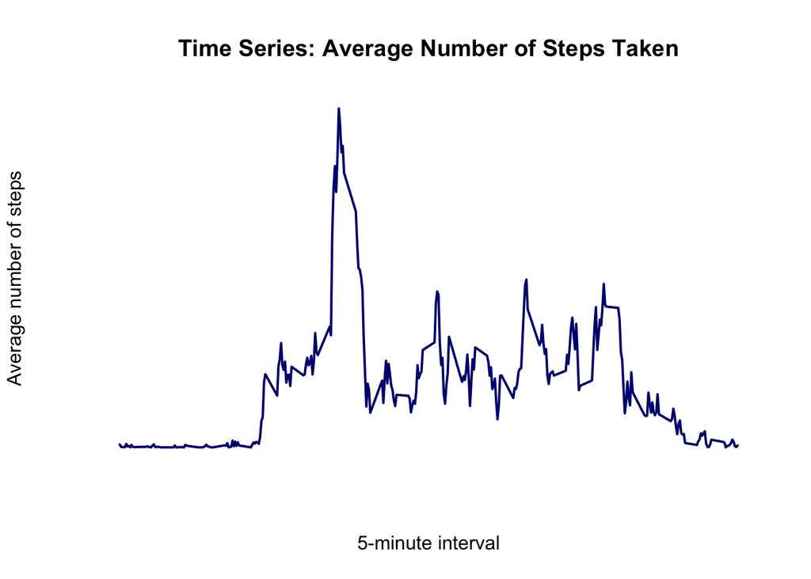

```r
avg_step <- aggregate(steps ~ interval, data = data, mean, na.rm = TRUE)
plot(avg_step$interval, avg_step$steps, type = "l", lwd = 2, col = "navy",
     main = "Time Series: Average Number of Steps Taken", axes = FALSE,
     xlab = "5-minute interval", ylab = "Average number of steps")
```

**2. Which 5-minute interval, on average across all the days in the dataset, contains the maximum number of steps?**

```r
avg_step$interval[which.max(avg_step$steps)]
```

```
## [1] 835
```

## Imputing missing values

Note that there are a number of days/intervals where there are missing values (coded as NA). The presence of missing days may introduce bias into some calculations or summaries of the data.

**1. Calculate and report the total number of missing values in the dataset (i.e. the total number of rows with NAs)**

```r
sum(is.na(data$steps))
```

```
## [1] 2304
```

There are 2304 missing values in the dataset.

**2. Devise a strategy for filling in all of the missing values in the dataset. The strategy does not need to be sophisticated. For example, you could use the mean/median for that day, or the mean for that 5-minute interval, etc.**

Strategy used: Means for the 5-minute intervals will serve as fillers for missing values.

**3. Create a new dataset that is equal to the original dataset but with the missing data filled in.**

```r
library(rlang)
library(dplyr)

data1 = data

for (i in avg_step$interval) {
     data1[data1$interval == i & is.na(data1$steps), ]$steps =
# Rows[condition on when step is na & interval is i, ]$steps
     avg_step$steps[avg_step$interval == i]
# avg_step$steps[condition on interval is i]
}

head(data1, 5)
```

```
##       steps       date interval
## 1 1.7169811 2012-10-01        0
## 2 0.3396226 2012-10-01        5
## 3 0.1320755 2012-10-01       10
## 4 0.1509434 2012-10-01       15
## 5 0.0754717 2012-10-01       20
```

```r
# Total number of steps
data2 = data1 %>%
     group_by(date) %>%
     summarise(total_steps = sum(steps))
data2
```

```
## # A tibble: 61 × 2
##    date       total_steps
##    <date>           <dbl>
##  1 2012-10-01      10766.
##  2 2012-10-02        126
##  3 2012-10-03      11352
##  4 2012-10-04      12116
##  5 2012-10-05      13294
##  6 2012-10-06      15420
##  7 2012-10-07      11015
##  8 2012-10-08      10766.
##  9 2012-10-09      12811
## 10 2012-10-10       9900
## # ℹ 51 more rows
```

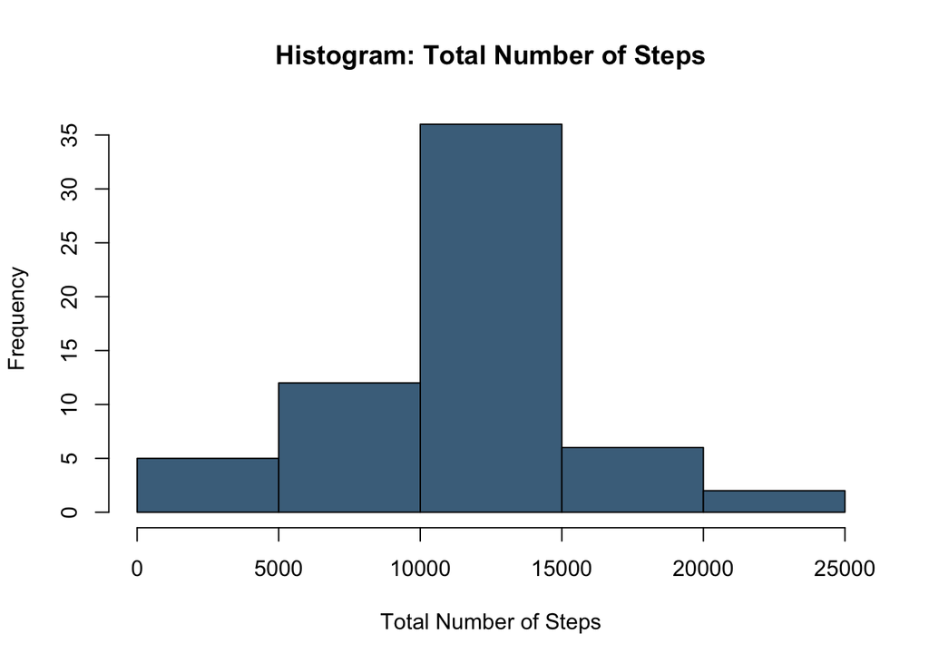

```r
# Histogram of the total number of steps
hist(data2$total_steps, main = "Histogram: Total Number of Steps", xlab= "Total Number of Steps",
     col= "skyblue4")
```

```r
# Mean number of steps
data3 = data1 %>%
     group_by(date) %>%
     summarise(total_steps = mean(steps))
data3
```

```
## # A tibble: 61 × 2
##    date       total_steps
##    <date>           <dbl>
##  1 2012-10-01      37.4
##  2 2012-10-02       0.438
##  3 2012-10-03      39.4
##  4 2012-10-04      42.1
##  5 2012-10-05      46.2
##  6 2012-10-06      53.5
##  7 2012-10-07      38.2
##  8 2012-10-08      37.4
##  9 2012-10-09      44.5
## 10 2012-10-10      34.4
## # ℹ 51 more rows
```

```r
# Median number of steps
data4 = data1 %>%
     group_by(date) %>%
     summarise(total_steps = median(steps))
data4
```

```
## # A tibble: 61 × 2
##    date       total_steps
##    <date>           <dbl>
##  1 2012-10-01        34.1
##  2 2012-10-02         0
##  3 2012-10-03         0
##  4 2012-10-04         0
##  5 2012-10-05         0
##  6 2012-10-06         0
##  7 2012-10-07         0
##  8 2012-10-08        34.1
##  9 2012-10-09         0
## 10 2012-10-10         0
## # ℹ 51 more rows
```

## Are there differences in activity patterns between weekdays and weekends?

For this part the weekdays() function may be of some help here. Use the dataset with the filled-in missing values for this part.

**1. Create a new factor variable in the dataset with two levels – “weekday” and “weekend” indicating whether a given date is a weekday or weekend day.**

```r
data1$date <-as.Date(data1$date)

weekdays <- c('Monday', 'Tuesday', 'Wednesday', 'Thursday', 'Friday')
data1$daytype <- factor((weekdays(data1$date) %in% weekdays),
         levels=c(TRUE, FALSE), labels=c('weekday', 'weekend'))

table(data1$daytype)
```

```
##
## weekday weekend
##   12960    4608
```

**2. Make a panel plot containing a time series plot (i.e. type = “l”) of the 5-minute interval (x-axis) and the average number of steps taken, averaged across all weekday days or weekend days (y-axis). See the README file in the GitHub repository to see an example of what this plot should look like using simulated data.**

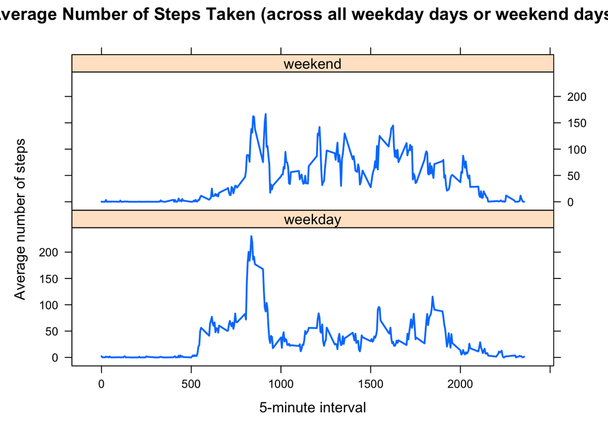

```r
avg_step2 <- aggregate(steps ~ interval + daytype, data = data1, mean, na.rm = TRUE)

library(lattice)
xyplot(steps ~ interval | daytype, data = avg_step2, type = "l", lwd = 2,
       layout = c(1, 2),
       xlab = "5-minute interval",
       ylab = "Average number of steps",
       main = "Average Number of Steps Taken (across all weekday days or weekend days)")
```